# Project 2: Public Health & Epidemiology

#### Additional Exploration 1: Stratified Boxplots by Sex and Retirement-Age Status

To understand whether the stay-at-home orders had a differential impact across demographic subgroups, I compare the distribution of the heart disease death proportion before and during the stay-at-home period, stratified by both biological sex and retirement-age status.

Because the sexDeaths table does not directly separate deaths by age group within a cause-of-death category, I use the retiree ratio (proportion of each county’s population aged 65 and older from the Census) as a continuous proxy for age burden, and then create a categorical split at the median to distinguish “high retiree” from “low retiree” counties.

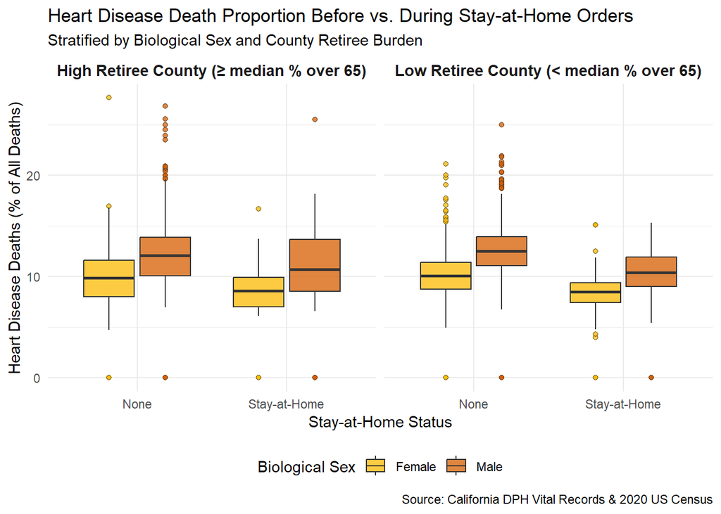

First, males (orange) show a consistently higher median heart disease death proportion than females (yellow) in every condition both before and during stay-at-home orders, and in both high and low-retiree counties. Males sit roughly at 12–13% while females sit at 9–10%, confirming the sex difference established in the line graph and ruling out the possibility that it was driven solely by seasonal or pandemic-era effects.

Third, high and low-retiree counties are nearly indistinguishable in their medians and interquartile ranges. The retiree ratio does not appear to meaningfully stratify heart disease death proportions at the county level, which is surprising given the well-known age–cardiovascular risk relationship. One explanation is that high-retiree counties are often small and rural, where other causes of death are also elevated (e.g., accidents, limited hospital access), keeping heart disease’s proportional share from rising above that of lower-retiree counties.

Fourth, outliers are more extreme in the “None” (pre-shutdown) period across all groups, with some counties showing proportions above 20–25%. These likely represent small-population counties where a handful of cardiac deaths in a single month produce volatile proportions which is the same suppression issue noted in the choropleth maps.

#### Additional Exploration 2: Correlation Test

I calculate the correlation between the county retiree ratio (proportion of residents aged 65+) and the proportion of deaths due to heart disease, to assess whether age composition of a county is associated with cardiovascular mortality burden.

```
##   correlation
## 1  -0.2333549
```

```
##
##  Pearson's product-moment correlation
##
## data:  htdDeaths$retireeRatio and htdDeaths$deathsHeartProportion
## t = -12.917, df = 2897, p-value < 0.00000000000000022
## alternative hypothesis: true correlation is not equal to 0
## 95 percent confidence interval:
##  -0.2674872 -0.1986377
## sample estimates:
##        cor
## -0.2333549
```

**Interpretation:** The correlation between the county retiree ratio and the proportion of deaths attributed to heart disease is r = −0.233 (t = −12.917, df = 2897, p < 0.001, 95% CI: −0.267 to −0.199). The result is highly statistically significant, but the direction is the opposite of what the individual-level age–cardiovascular risk relationship would predict: counties with a higher proportion of residents aged 65 and older actually show a lower proportion of deaths attributed to heart disease.

This is a textbook example of the ecological fallacy which is the danger of inferring individual-level relationships from aggregate (county-level) data. Several mechanisms likely contribute to this negative ecological correlation:

- **Competing causes:** Older rural counties tend to have elevated mortality from respiratory disease, diabetes, and Alzheimer’s, all of which compete with heart disease for share of total deaths. Even if absolute cardiac deaths are high, heart disease may represent a smaller proportion of the total in counties with many co-occurring causes.
- **Denominator inflation:** High-retiree counties, which are often small and rural, may have higher overall death rates from multiple causes, depressing any single cause’s proportional share.
- **Access to care:** Counterintuitively, counties with many retirees may have developed stronger primary care infrastructure for that population, leading to better-managed cardiovascular disease and fewer acute cardiac deaths relative to other causes.

Despite being statistically significant at p < 0.001, the effect size is modest (r = −0.23, R² ≈ 0.054), meaning the retiree ratio explains only about 5% of the variance in heart disease death proportions. The retiree ratio should still be included as a covariate in any predictive model because its relationship with the outcome is real and significant but it is not a strong standalone predictor, and its negative direction must be interpreted carefully in context.

#### Additional Exploration 3: Scatterplot of Retiree Ratio vs. Heart Disease Proportion

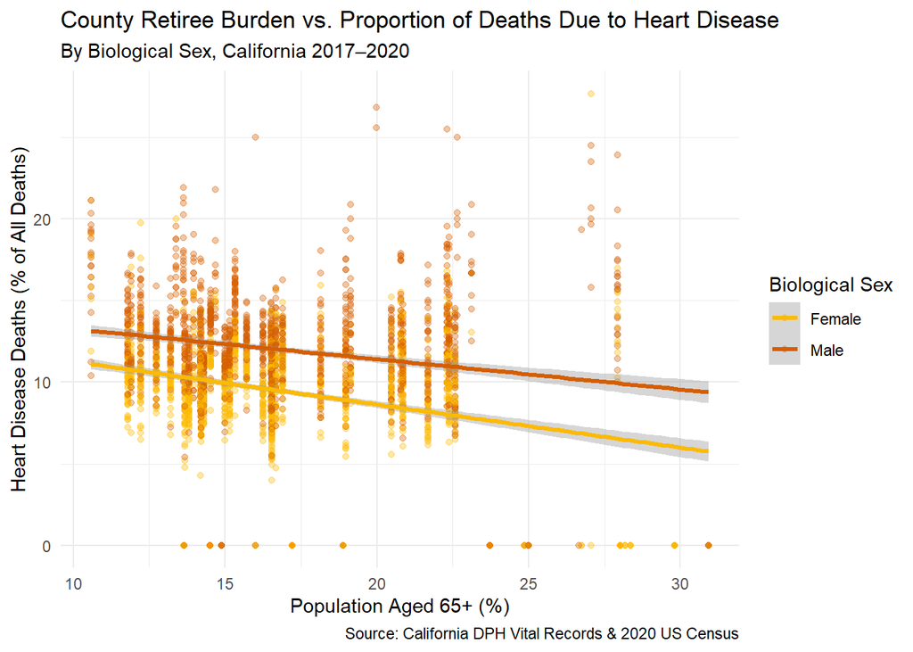

**Interpretation:** The scatterplot visually confirms and extends the correlation result (r = −0.233, p < 0.001). Several features are worth noting.

Both regression lines slope downward, running from upper-left to lower-right across the full range of retiree burden (~10% to ~31% aged 65+). This confirms the negative ecological correlation: as a county’s elderly share of population increases, heart disease’s proportion of all deaths decreases. The male line (dark orange) sits consistently above the female line (yellow) at every level of retiree burden, reinforcing the sex difference established in the line graph and boxplots.

Taken together with the correlation test, these results indicate that the retiree ratio captures a real but modest ecological signal that runs counter to individual-level expectations, a finding consistent with the ecological fallacy and with the competing, causes mechanism discussed above. The retiree ratio should be retained as a covariate in any formal model, with its negative direction interpreted at the county level rather than as a statement about individual cardiovascular risk.

### Data Science Question

How did California’s mandatory COVID-19 stay-at-home orders affect the proportion of deaths attributed to heart disease across counties, and was this effect moderated bycounty-level age structure and the biological sex of the decedent?

### Data Science Hypothesis

To test this formally, we would fit a spatial lag regression or random forest model predicting the monthly proportion of heart disease deaths per county, with predictors including: stay-at-home status (binary), biological sex, retiree ratio, female-to-male population ratio (to control for county sex composition), total county population size, spatial lag of the outcome, and month/year indicators to control for seasonality and secular trends. We would additionally consider temporal lag variables given the strong seasonal patterns observed in the line graph. A significant positive interaction between stay-at-home status and retiree ratio, and/or stay-at-home status and female sex, would support our hypothesis.